# R Notebook - Belief in Change Scale Analyses

## Interitem and item-total correlations

```r
itemtotal <- cor(change2, use = "pairwise.complete.obs")
itemtotal
```

```
              change1_1 change1_2R change1_3 change1_4R change1_5 change1_6R change1_7 change1_8 change1_9R change2_1 change2_2R
change1_1     1.0000000  0.5223877 0.6589260  0.5852896 0.5342838  0.6864213 0.7161076 0.5774156  0.6251198 0.4238787  0.2458611
change1_2R    0.5223877  1.0000000 0.3916518  0.4554939 0.4610633  0.5025255 0.4872780 0.3101854  0.6016971 0.2564671  0.3268502
change1_3     0.6589260  0.3916518 1.0000000  0.4998752 0.4900850  0.6339432 0.6875363 0.3924210  0.4818019 0.4138606  0.2409900
change1_4R    0.5852896  0.4554939 0.4998752  1.0000000 0.6290733  0.7576615 0.5239805 0.5944853  0.7835700 0.3650387  0.3673131
change1_5     0.5342838  0.4610633 0.4900850  0.6290733 1.0000000  0.5367473 0.6068598 0.5910113  0.6494116 0.4138761  0.2666808
change1_6R    0.6864213  0.5025255 0.6339432  0.7576615 0.5367473  1.0000000 0.6056415 0.6229845  0.8074280 0.3448168  0.2954857
change1_7     0.7161076  0.4872780 0.6875363  0.5239805 0.6068598  0.6056415 1.0000000 0.5830947  0.5641690 0.3916582  0.1982202
change1_8     0.5774156  0.3101854 0.3924210  0.5944853 0.5910113  0.6229845 0.5830947 1.0000000  0.6709509 0.3602284  0.2663065
change1_9R    0.6251198  0.6016971 0.4818019  0.7835700 0.6494116  0.8074280 0.5641690 0.6709509  1.0000000 0.3151035  0.4097370
change2_1     0.4238787  0.2564671 0.4138606  0.3650387 0.4138761  0.3448168 0.3916582 0.3602284  0.3151035 1.0000000  0.3986882
change2_2R    0.2458611  0.3268502 0.2409900  0.3673131 0.2666808  0.2954857 0.1982202 0.2663065  0.4097370 0.3986882  1.0000000
change2_3     0.4933364  0.3742290 0.5278237  0.4374830 0.4893547  0.4833641 0.5499130 0.3573527  0.4264213 0.7067876  0.3976611
change2_4     0.3703182  0.2466580 0.4100346  0.3388172 0.3884461  0.3556414 0.4753572 0.3701189  0.3038240 0.7041242  0.3305765
change2_5R    0.4146577  0.4742292 0.4206707  0.5167057 0.4552441  0.4936987 0.4483717 0.3624716  0.5714806 0.5453215  0.6290764
change2_6     0.4082315  0.3411149 0.3632974  0.4048838 0.4490572  0.4835070 0.4678244 0.3668859  0.4289973 0.5050001  0.3437677
change2_7R    0.4011242  0.4621688 0.4016847  0.4893868 0.4808470  0.4568288 0.3939794 0.3283918  0.5856243 0.4589958  0.4706272
change2_8     0.5071258  0.3624113 0.3571956  0.5121692 0.4751131  0.4195401 0.4586658 0.5687426  0.4389585 0.4733324  0.4041605
change2_9R    0.4629084  0.3444878 0.4259672  0.4941991 0.3445348  0.3965041 0.4585626 0.4907003  0.4426366 0.5485164  0.4452312
change2_10    0.2954685  0.3797825 0.3486237  0.4193753 0.3653282  0.2747326 0.3562067 0.3055030  0.3255793 0.4050709  0.3897197
scalefull     0.7211798  0.6184654 0.6629228  0.7601061 0.7003258  0.7424107 0.7184529 0.6765532  0.7721252 0.6876238  0.5887458
scalegeneral  0.8185571  0.6773414 0.7206386  0.8306445 0.7662373  0.8709189 0.7911930 0.7541302  0.8810669 0.4558142  0.3763611
scalepersonal 0.5334051  0.4776426 0.5162199  0.5870374 0.5412790  0.5261081 0.5510967 0.5111339  0.5671379 0.7668609  0.6705345
              change2_3 change2_4 change2_5R change2_6 change2_7R change2_8 change2_9R change2_10 scalefull scalegeneral scalepersonal
change1_1     0.4933364 0.3703182  0.4146577 0.4082315  0.4011242 0.5071258  0.4629084  0.2954685 0.7211798    0.8185571     0.5334051
change1_2R    0.3742290 0.2466580  0.4742292 0.3411149  0.4621688 0.3624113  0.3444878  0.3797825 0.6184654    0.6773414     0.4776426
change1_3     0.5278237 0.4100346  0.4206707 0.3632974  0.4016847 0.3571956  0.4259672  0.3486237 0.6629228    0.7206386     0.5162199
change1_4R    0.4374830 0.3388172  0.5167057 0.4048838  0.4893868 0.5121692  0.4941991  0.4193753 0.7601061    0.8306445     0.5870374
change1_5     0.4893547 0.3884461  0.4552441 0.4490572  0.4808470 0.4751131  0.3445348  0.3653282 0.7003258    0.7662373     0.5412790
change1_6R    0.4833641 0.3556414  0.4936987 0.4835070  0.4568288 0.4195401  0.3965041  0.2747326 0.7424107    0.8709189     0.5261081
```

[output cut: 16 more lines]

```r
apa.cor.table(itemtotal, show.conf.interval = FALSE, filename = "cor.doc")
```

```
The ability to suppress reporting of reporting confidence intervals has been deprecated in this version.
The function argument show.conf.interval will be removed in a later version.


Means, standard deviations, and correlations with confidence intervals


  Variable          M    SD   1            2            3            4           5           6            7            8
  1. change1_1      0.55 0.18

  2. change1_2R     0.46 0.17 .44*
                              [.02, .72]

  3. change1_3      0.50 0.17 .74**        .23
                              [.47, .89]   [-.21, .59]

  4. change1_4R     0.56 0.17 .60**        .40          .39
                              [.24, .82]   [-.03, .70]  [-.04, .70]

  5. change1_5      0.53 0.16 .55**        .35          .41          .66**
                              [.17, .79]   [-.08, .68]  [-.02, .71]  [.33, .85]

  6. change1_6R     0.56 0.19 .78**        .46*         .62**        .84**       .60**
                              [.54, .91]   [.05, .74]   [.28, .83]   [.65, .93]  [.24, .81]

  7. change1_7      0.55 0.17 .83**        .33          .78**        .45*        .61**       .65**
                              [.63, .93]   [-.10, .66]  [.54, .90]   [.04, .73]  [.26, .82]  [.31, .84]

  8. change1_8      0.50 0.18 .62**        .12          .29          .67**       .63**       .67**        .57**
                              [.27, .83]   [-.32, .51]  [-.15, .63]  [.35, .85]  [.28, .83]  [.34, .85]   [.19, .80]

  9. change1_9R     0.58 0.19 .63**        .59**        .36          .89**       .67**       .88**        .48*         .68**
                              [.28, .83]   [.23, .81]   [-.07, .68]  [.74, .95]  [.35, .85]  [.74, .95]   [.07, .75]   [.36, .85]

  10. change2_1     0.50 0.18 -.22         -.43*        -.06         -.34        -.19        -.36         -.15         -.24
                              [-.59, .22]  [-.72, -.01] [-.47, .37]  [-.66, .10] [-.57, .25] [-.68, .07]  [-.54, .29]  [-.60, .20]

  11. change2_2R    0.41 0.18 -.48*        -.09         -.43*        -.15        -.37        -.33         -.57**       -.33
                              [-.75, -.07] [-.49, .34]  [-.72, -.01] [-.54, .29] [-.68, .07] [-.66, .10]  [-.80, -.19] [-.66, .10]

```

[output cut: 85 more lines]

```








 [ reached getOption("max.print") -- omitted 24 rows ]

Note. M and SD are used to represent mean and standard deviation, respectively.
Values in square brackets indicate the 95% confidence interval.
The confidence interval is a plausible range of population correlations
that could have caused the sample correlation (Cumming, 2014).
* indicates p < .05. ** indicates p < .01.
```

## Descriptive stats for scale items and scale scores

(reran to get descriptives for scale scores too)

```r
describe(change2)
```

```
              vars   n mean   sd median trimmed  mad  min max range  skew kurtosis   se
change1_1        1 122 4.16 0.56   4.00    4.16 0.00 2.00   5  3.00 -0.52     2.51 0.05
change1_2R       2 122 4.25 0.77   4.00    4.38 0.74 2.00   5  3.00 -1.11     1.39 0.07
change1_3        3 122 4.18 0.62   4.00    4.19 0.00 1.00   5  4.00 -1.38     6.37 0.06
change1_4R       4 122 3.93 0.74   4.00    3.96 0.00 2.00   5  3.00 -0.49     0.21 0.07
change1_5        5 122 4.27 0.58   4.00    4.28 0.00 2.00   5  3.00 -0.60     2.22 0.05
change1_6R       6 122 4.16 0.68   4.00    4.24 0.00 2.00   5  3.00 -0.83     1.48 0.06
change1_7        7 122 4.22 0.49   4.00    4.18 0.00 2.00   5  3.00  0.03     2.39 0.04
change1_8        8 122 4.04 0.72   4.00    4.12 0.00 1.00   5  4.00 -1.24     3.20 0.07
change1_9R       9 122 4.15 0.69   4.00    4.22 0.00 2.00   5  3.00 -0.80     1.35 0.06
change2_1       10 121 4.14 0.75   4.00    4.22 0.00 2.00   5  3.00 -0.71     0.46 0.07
change2_2R      11 121 3.59 0.95   4.00    3.62 0.00 1.00   5  4.00 -0.53    -0.55 0.09
change2_3       12 121 4.19 0.58   4.00    4.22 0.00 2.00   5  3.00 -0.29     0.85 0.05
change2_4       13 121 4.12 0.67   4.00    4.19 0.00 2.00   5  3.00 -0.64     1.11 0.06
change2_5R      14 120 3.89 0.72   4.00    3.92 0.00 2.00   5  3.00 -0.51     0.38 0.07
change2_6       15 121 4.12 0.64   4.00    4.19 0.00 2.00   5  3.00 -0.68     1.59 0.06
change2_7R      16 121 4.07 0.65   4.00    4.11 0.00 2.00   5  3.00 -0.60     1.13 0.06
change2_8       17 121 3.72 0.80   4.00    3.74 0.00 2.00   5  3.00 -0.34    -0.28 0.07
change2_9R      18 121 3.54 1.02   4.00    3.56 1.48 1.00   5  4.00 -0.36    -0.89 0.09
change2_10      19 121 3.50 0.92   4.00    3.52 1.48 1.00   5  4.00 -0.39    -0.58 0.08
scalefull       20 120 4.02 0.50   3.95    4.00 0.39 2.95   5  2.05  0.27    -0.53 0.05
scalegeneral    21 122 4.15 0.51   4.00    4.16 0.33 2.33   5  2.67 -0.26     0.85 0.05
scalepersonal   22 120 3.89 0.57   3.85    3.89 0.52 2.30   5  2.70 -0.06    -0.12 0.05
```

# Interitem correlations (write to CSV)

```r
cortable <- cor(change, use = "pairwise.complete.obs")
write.csv(cortable, file = "Cor Table.csv")
```

# Factor Analysis

## All items

### CFA - two factor no items removed

```r
model.2f <- 'f1 =~ NA*change1_1 + change1_2R + change1_3 + change1_4R + change1_5 + change1_6R + change1_7 + change1_8 + change1_9R
f1 ~~ 1*f1
            f2 =~ NA*change2_1 + change2_2R + change2_3 + change2_4 + change2_5R + change2_6 + change2_7R + change2_8 + change2_9R + change2_10
f2 ~~ 1*f2'
fit.model.2f <- cfa(model.2f, change)
summary(fit.model.2f, fit.measures = TRUE, standardized = TRUE)
```

```
lavaan (0.5-23.1097) converged normally after  45 iterations

                                                  Used       Total
  Number of observations                           120         173

  Estimator                                         ML
  Minimum Function Test Statistic              447.100
  Degrees of freedom                               151
  P-value (Chi-square)                           0.000

Model test baseline model:

  Minimum Function Test Statistic             1796.107
  Degrees of freedom                               171
  P-value                                        0.000

User model versus baseline model:

  Comparative Fit Index (CFI)                    0.818
  Tucker-Lewis Index (TLI)                       0.794

Loglikelihood and Information Criteria:

  Loglikelihood user model (H0)              -1745.073
  Loglikelihood unrestricted model (H1)      -1521.523

  Number of free parameters                         39
  Akaike (AIC)                                3568.146
  Bayesian (BIC)                              3676.858
  Sample-size adjusted Bayesian (BIC)         3553.559

Root Mean Square Error of Approximation:

  RMSEA                                          0.128
  90 Percent Confidence Interval          0.114  0.142
  P-value RMSEA <= 0.05                          0.000

Standardized Root Mean Square Residual:

  SRMR                                           0.071
```

[output cut: 90 more lines]

```
    0.472
    0.244
    0.438
    0.471
    0.238
    0.416
    0.676
    0.323
    0.348
    0.383
    0.529
    0.476
    0.480
    0.526
    0.625
```

```r
resid(fit.model.2f, type = "cor")
```

```
$type
[1] "cor.bollen"

$cor
           chn1_1 ch1_2R chn1_3 ch1_4R chn1_5 ch1_6R chn1_7 chn1_8
change1_1   0.000
change1_2R  0.042  0.000
change1_3   0.123 -0.026  0.000
change1_4R -0.063 -0.048 -0.063  0.000
change1_5  -0.037  0.016 -0.007  0.031  0.000
change1_6R  0.003 -0.029  0.040  0.040 -0.096  0.000
change1_7   0.127  0.028  0.175 -0.094  0.061 -0.047  0.000
change1_8   0.007 -0.134 -0.104 -0.006  0.063 -0.009  0.039  0.000
change1_9R -0.061  0.068 -0.115  0.063  0.015  0.048 -0.091  0.036
change2_1   0.004 -0.069  0.050 -0.081  0.028 -0.121 -0.007 -0.030
change2_2R -0.069  0.083 -0.033  0.034 -0.024 -0.054 -0.102 -0.026
change2_3   0.035  0.018  0.130 -0.043  0.065 -0.024  0.113 -0.066
change2_4  -0.079 -0.103  0.020 -0.133 -0.027 -0.142  0.046 -0.046
change2_5R -0.022  0.135  0.041  0.057  0.051  0.010  0.031 -0.042
change2_6   0.039  0.052  0.041  0.027  0.105  0.078  0.114  0.030
change2_7R -0.001  0.149  0.052  0.066  0.109  0.011  0.010 -0.044
change2_8   0.106  0.050  0.008  0.093  0.103 -0.025  0.074  0.199
change2_9R  0.082  0.048  0.095  0.091 -0.007 -0.026  0.096  0.137
change2_10 -0.046  0.115  0.053  0.067  0.048 -0.103  0.029 -0.007
           ch1_9R chn2_1 ch2_2R chn2_3 chn2_4 ch2_5R chn2_6 ch2_7R
change1_1
change1_2R
change1_3
change1_4R
change1_5
change1_6R
change1_7
change1_8
change1_9R  0.000
change2_1  -0.153  0.000
change2_2R  0.059 -0.038  0.000
change2_3  -0.083  0.086 -0.069  0.000
change2_4  -0.196  0.093 -0.128  0.113  0.000
change2_5R  0.086 -0.055  0.182 -0.037 -0.029  0.000
change2_6   0.020  0.043 -0.017  0.017  0.060 -0.027  0.000
```

[output cut: 19 more lines]

```
change2_6
change2_7R
change2_8   0.000
change2_9R  0.108  0.000
change2_10  0.098  0.081  0.000

$mean
 change1_1 change1_2R  change1_3 change1_4R  change1_5 change1_6R
         0          0          0          0          0          0
 change1_7  change1_8 change1_9R  change2_1 change2_2R  change2_3
         0          0          0          0          0          0
 change2_4 change2_5R  change2_6 change2_7R  change2_8 change2_9R
         0          0          0          0          0          0
change2_10
         0
```

```r
reliability(fit.model.2f)
```

```
              f1        f2     total
alpha  0.9206542 0.9050732 0.9387006
omega  0.9251652 0.9051057 0.9468502
omega2 0.9251652 0.9051057 0.9468502
omega3 0.9295067 0.8975977 0.9286566
avevar 0.5860736 0.4925036 0.5291211
```

### EFA - no items removed

#### Scree plot

```
Parallel analysis suggests that the number of factors =  6  and the number of components =  NA
```

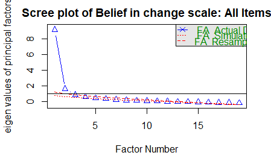

```r
set.seed(123)
parallel = fa.parallel(change,
 fm = 'ml',
 fa = 'fa',
 n.iter = 50,
 main = "Scree plot of Belief in change scale: All Items",
 SMC = TRUE)
```

#### EFA - all items - one factor

```r
efa_full_1 <- fa(change, nfactors = 1, fm = "ml", rotate = "geominQ")
chi_full_1 <- efa_full_1$chi # <- #get Chi square value
dof_full_1 <- efa_full_1$dof # <- Getting degrees of freedom
efa_full_1
```

```
Factor Analysis using method =  ml
Call: fa(r = change, nfactors = 1, rotate = "geominQ", fm = "ml")
Standardized loadings (pattern matrix) based upon correlation matrix
            ML1   h2   u2 com
change1_1  0.75 0.56 0.44   1
change1_2R 0.60 0.36 0.64   1
change1_3  0.68 0.46 0.54   1
change1_4R 0.77 0.60 0.40   1
change1_5  0.72 0.51 0.49   1
change1_6R 0.78 0.61 0.39   1
change1_7  0.74 0.55 0.45   1
change1_8  0.69 0.47 0.53   1
change1_9R 0.80 0.63 0.37   1
change2_1  0.62 0.39 0.61   1
change2_2R 0.50 0.25 0.75   1
change2_3  0.73 0.53 0.47   1
change2_4  0.64 0.42 0.58   1
change2_5R 0.73 0.53 0.47   1
change2_6  0.63 0.39 0.61   1
change2_7R 0.69 0.48 0.52   1
change2_8  0.69 0.48 0.52   1
change2_9R 0.66 0.43 0.57   1
change2_10 0.55 0.31 0.69   1

                ML1
SS loadings    8.96
Proportion Var 0.47

Mean item complexity =  1
Test of the hypothesis that 1 factor is sufficient.

The degrees of freedom for the null model are  171  and the objective function was  14.85 with Chi Square of  2448.3
The degrees of freedom for the model are 152  and the objective function was  5.36

The root mean square of the residuals (RMSR) is  0.1
The df corrected root mean square of the residuals is  0.11

The harmonic number of observations is  121 with the empirical chi square  415.75  with prob <  2.3e-26
The total number of observations was  173  with Likelihood Chi Square =  879.15  with prob <  1e-102

Tucker Lewis Index of factoring reliability =  0.639
RMSEA index =  0.172  and the 90 % confidence intervals are  0.156 0.178
BIC =  95.85
Fit based upon off diagonal values = 0.96
Measures of factor score adequacy
                                                   ML1
Correlation of (regression) scores with factors   0.97
Multiple R square of scores with factors          0.95
Minimum correlation of possible factor scores     0.90
```

#### EFA - all items - two factors

```r
efa_full_2 <- fa(change, nfactors = 2, fm = "ml", rotate = "geominQ")
chi_full_2 <- efa_full_2$chi # <- #get Chi square value
dof_full_2 <- efa_full_2$dof # <- Getting degrees of freedom
efa_full_2
```

```
Factor Analysis using method =  ml
Call: fa(r = change, nfactors = 2, rotate = "geominQ", fm = "ml")
Standardized loadings (pattern matrix) based upon correlation matrix
             ML1   ML2   h2   u2 com
change1_1   0.67  0.13 0.57 0.43 1.1
change1_2R  0.59  0.06 0.39 0.61 1.0
change1_3   0.48  0.26 0.44 0.56 1.5
change1_4R  0.84  0.00 0.71 0.29 1.0
change1_5   0.61  0.17 0.53 0.47 1.1
change1_6R  0.89 -0.03 0.76 0.24 1.0
change1_7   0.54  0.27 0.53 0.47 1.5
change1_8   0.68  0.06 0.52 0.48 1.0
change1_9R  0.98 -0.11 0.85 0.15 1.0
change2_1  -0.05  0.82 0.63 0.37 1.0
change2_2R  0.21  0.36 0.26 0.74 1.6
change2_3   0.07  0.82 0.74 0.26 1.0
change2_4  -0.15  0.97 0.80 0.20 1.0
change2_5R  0.30  0.55 0.58 0.42 1.5
change2_6   0.20  0.54 0.45 0.55 1.3
change2_7R  0.35  0.44 0.49 0.51 1.9
change2_8   0.24  0.56 0.51 0.49 1.4
change2_9R  0.27  0.47 0.44 0.56 1.6
change2_10  0.13  0.50 0.34 0.66 1.1

                       ML1  ML2
SS loadings           5.72 4.82
Proportion Var        0.30 0.25
Cumulative Var        0.30 0.55
Proportion Explained  0.54 0.46
Cumulative Proportion 0.54 1.00

 With factor correlations of
     ML1  ML2
ML1 1.00 0.57
ML2 0.57 1.00

Mean item complexity =  1.2
Test of the hypothesis that 2 factors are sufficient.

The degrees of freedom for the null model are  171  and the objective function was  14.85 with Chi Square of  2448.3
The degrees of freedom for the model are 134  and the objective function was  3.26

The root mean square of the residuals (RMSR) is  0.06
The df corrected root mean square of the residuals is  0.07

The harmonic number of observations is  121 with the empirical chi square  170.51  with prob <  0.018
The total number of observations was  173  with Likelihood Chi Square =  533.09  with prob <  5.4e-49

Tucker Lewis Index of factoring reliability =  0.774
RMSEA index =  0.136  and the 90 % confidence intervals are  0.12 0.143
BIC =  -157.45
Fit based upon off diagonal values = 0.98
Measures of factor score adequacy
                                                   ML1  ML2
Correlation of (regression) scores with factors   0.97 0.96
Multiple R square of scores with factors          0.95 0.93
Minimum correlation of possible factor scores     0.89 0.86
```

#### EFA - all items - three factors

```r
efa_full_3 <- fa(change, nfactors = 3, fm = "ml", rotate = "geominQ")
chi_full_3 <- efa_full_3$chi # <- #get Chi square value
dof_full_3 <- efa_full_3$dof # <- Getting degrees of freedom
efa_full_3
```

```
Factor Analysis using method =  ml
Call: fa(r = change, nfactors = 3, rotate = "geominQ", fm = "ml")
Standardized loadings (pattern matrix) based upon correlation matrix
            ML1   ML2   ML3   h2    u2 com
change1_1  0.63  0.12  0.42 0.70 0.302 1.8
change1_2R 0.55  0.25  0.00 0.40 0.598 1.4
change1_3  0.59 -0.04  0.41 0.58 0.418 1.8
change1_4R 0.69  0.38  0.02 0.69 0.305 1.6
change1_5  0.65  0.17  0.13 0.53 0.471 1.2
change1_6R 0.67  0.37  0.21 0.77 0.234 1.8
change1_7  0.64 -0.01  0.46 0.71 0.287 1.8
change1_8  0.59  0.25  0.19 0.53 0.469 1.6
change1_9R 0.72  0.56 -0.05 0.91 0.087 1.9
change2_1  0.73 -0.40 -0.02 0.62 0.380 1.6
change2_2R 0.60  0.04 -0.41 0.45 0.551 1.8
change2_3  0.82 -0.36  0.05 0.74 0.262 1.4
change2_4  0.78 -0.50  0.00 0.77 0.229 1.7
change2_5R 0.83 -0.03 -0.31 0.70 0.298 1.3
change2_6  0.67 -0.16  0.02 0.45 0.553 1.1
change2_7R 0.76  0.05 -0.29 0.60 0.396 1.3
change2_8  0.72 -0.14 -0.04 0.51 0.488 1.1
change2_9R 0.68 -0.09 -0.07 0.45 0.546 1.1
change2_10 0.60 -0.14 -0.15 0.37 0.632 1.2

                       ML1  ML2  ML3
SS loadings           8.96 1.43 1.11
Proportion Var        0.47 0.08 0.06
Cumulative Var        0.47 0.55 0.60
Proportion Explained  0.78 0.12 0.10
Cumulative Proportion 0.78 0.90 1.00

 With factor correlations of
     ML1  ML2  ML3
ML1 1.00 0.11 0.16
ML2 0.11 1.00 0.18
ML3 0.16 0.18 1.00

Mean item complexity =  1.5
Test of the hypothesis that 3 factors are sufficient.

The degrees of freedom for the null model are  171  and the objective function was  14.85 with Chi Square of  2448.3
The degrees of freedom for the model are 117  and the objective function was  2.34

The root mean square of the residuals (RMSR) is  0.05
The df corrected root mean square of the residuals is  0.06

The harmonic number of observations is  121 with the empirical chi square  87.74  with prob <  0.98
The total number of observations was  173  with Likelihood Chi Square =  381.41  with prob <  9.2e-30

Tucker Lewis Index of factoring reliability =  0.828
RMSEA index =  0.119  and the 90 % confidence intervals are  0.102 0.128
BIC =  -221.53
Fit based upon off diagonal values = 0.99
Measures of factor score adequacy
                                                   ML1  ML2  ML3
Correlation of (regression) scores with factors   0.98 0.93 0.87
Multiple R square of scores with factors          0.97 0.87 0.75
Minimum correlation of possible factor scores     0.93 0.75 0.50
```

#### 1-factor & 2-factor Model Comparison

```r
chi_diff <- chi_full_1 - chi_full_2
dof_diff <- dof_full_1 - dof_full_2
pchisq(chi_diff, df=dof_diff, lower.tail = FALSE)
```

```
[1] 7.550373e-42
```

#### 2-factor & 3-factor Model Comparison

```r
chi_diff <- chi_full_2 - chi_full_3
dof_diff <- dof_full_2 - dof_full_3
pchisq(chi_diff, df=dof_diff, lower.tail = FALSE)
```

```
[1] 1.227792e-10
```

The p-value for a chi-square difference (X^2 = 82.78, df = 17) test of 1.227792e-10 is an indication that the the 3-factor model has a much better fit than the 2-factor model.

### CFA - one factor

```r
model.1f <- 'f1 =~ change1_1 + change1_2R + change1_3 + change1_4R + change1_5 + change1_6R + change1_7 + change1_8 + change1_9R + change2_1 + change2_2R + change2_3 + change2_4 + change2_5R + change2_6 + change2_7R + change2_8 + change2_9R + change2_10'
fit.model.1f <- cfa(model.1f, change)
summary(fit.model.1f, fit.measures = TRUE, standardized = TRUE)
```

```
lavaan (0.5-23.1097) converged normally after  47 iterations

                                                  Used       Total
  Number of observations                           120         173

  Estimator                                         ML
  Minimum Function Test Statistic              648.728
  Degrees of freedom                               152
  P-value (Chi-square)                           0.000

Model test baseline model:

  Minimum Function Test Statistic             1796.107
  Degrees of freedom                               171
  P-value                                        0.000

User model versus baseline model:

  Comparative Fit Index (CFI)                    0.694
  Tucker-Lewis Index (TLI)                       0.656

Loglikelihood and Information Criteria:

  Loglikelihood user model (H0)              -1845.887
  Loglikelihood unrestricted model (H1)      -1521.523

  Number of free parameters                         38
  Akaike (AIC)                                3767.773
  Bayesian (BIC)                              3873.698
  Sample-size adjusted Bayesian (BIC)         3753.560

Root Mean Square Error of Approximation:

  RMSEA                                          0.165
  90 Percent Confidence Interval          0.152  0.178
  P-value RMSEA <= 0.05                          0.000

Standardized Root Mean Square Residual:

  SRMR                                           0.095
```

[output cut: 36 more lines]

```
   .change1_6R        0.185    0.026    7.091    0.000    0.185    0.393
   .change1_7         0.108    0.015    7.227    0.000    0.108    0.449
   .change1_8         0.278    0.038    7.374    0.000    0.278    0.532
   .change1_9R        0.176    0.025    7.022    0.000    0.176    0.369
   .change2_1         0.328    0.044    7.461    0.000    0.328    0.597
   .change2_2R        0.678    0.089    7.601    0.000    0.678    0.745
   .change2_3         0.159    0.022    7.271    0.000    0.159    0.471
   .change2_4         0.257    0.034    7.439    0.000    0.257    0.580
   .change2_5R        0.241    0.033    7.266    0.000    0.241    0.469
   .change2_6         0.215    0.029    7.439    0.000    0.215    0.579
   .change2_7R        0.224    0.030    7.359    0.000    0.224    0.522
   .change2_8         0.329    0.045    7.357    0.000    0.329    0.521
   .change2_9R        0.579    0.078    7.416    0.000    0.579    0.561
   .change2_10        0.576    0.076    7.557    0.000    0.576    0.691
    f1                0.176    0.037    4.725    0.000    1.000    1.000
```

```r
resid(fit.model.1f, type = "cor")
```

```
$type
[1] "cor.bollen"

$cor
           chn1_1 ch1_2R chn1_3 ch1_4R chn1_5 ch1_6R chn1_7 chn1_8 ch1_9R chn2_1 ch2_2R chn2_3 chn2_4 ch2_5R chn2_6 ch2_7R chn2_8 ch2_9R
change1_1   0.000
change1_2R  0.073  0.000
change1_3   0.154 -0.016  0.000
change1_4R  0.010 -0.008 -0.021  0.000
change1_5  -0.001  0.029  0.005  0.078  0.000
change1_6R  0.105  0.033  0.107  0.157 -0.022  0.000
change1_7   0.162  0.040  0.185 -0.048  0.074  0.027  0.000
change1_8   0.067 -0.101 -0.070  0.066  0.102  0.090  0.076  0.000
change1_9R  0.032  0.124 -0.056  0.171  0.081  0.188 -0.026  0.127  0.000
change2_1  -0.044 -0.120 -0.010 -0.124 -0.033 -0.145 -0.072 -0.071 -0.185  0.000
change2_2R -0.130  0.025 -0.099 -0.023 -0.093 -0.097 -0.175 -0.079  0.010  0.077  0.000
change2_3  -0.050 -0.064  0.036 -0.124 -0.032 -0.084  0.009 -0.140 -0.152  0.253  0.032  0.000
change2_4  -0.114 -0.144 -0.028 -0.162 -0.076 -0.150 -0.006 -0.074 -0.211  0.299  0.004  0.306  0.000
change2_5R -0.129  0.036 -0.072 -0.046 -0.066 -0.074 -0.093 -0.136 -0.008  0.083  0.261  0.080  0.133  0.000
change2_6  -0.064 -0.042 -0.065 -0.073 -0.006 -0.005 -0.003 -0.060 -0.071  0.156  0.046  0.110  0.193  0.039  0.000
change2_7R -0.115  0.046 -0.066 -0.044 -0.014 -0.082 -0.119 -0.145  0.036  0.024  0.122  0.098  0.030  0.169 -0.034  0.000
change2_8  -0.010 -0.055 -0.112 -0.020 -0.022 -0.120 -0.057  0.097 -0.111  0.047  0.059  0.007  0.183  0.028  0.009  0.052  0.000
change2_9R -0.030 -0.052 -0.020 -0.017 -0.127 -0.118 -0.031  0.038 -0.082  0.127  0.110  0.036  0.027  0.043 -0.054  0.115  0.146  0.000
change2_10 -0.119  0.046 -0.027 -0.003 -0.034 -0.158 -0.058 -0.072 -0.115  0.076  0.120 -0.025  0.137  0.076  0.092  0.102  0.155  0.135
           ch2_10
change1_1
change1_2R
change1_3
change1_4R
change1_5
change1_6R
change1_7
change1_8
change1_9R
change2_1
change2_2R
change2_3
change2_4
change2_5R
change2_6
change2_7R
change2_8
change2_9R
change2_10  0.000

$mean
 change1_1 change1_2R  change1_3 change1_4R  change1_5 change1_6R  change1_7  change1_8 change1_9R  change2_1 change2_2R  change2_3
         0          0          0          0          0          0          0          0          0          0          0          0
 change2_4 change2_5R  change2_6 change2_7R  change2_8 change2_9R change2_10
         0          0          0          0          0          0          0
```

## Removing items

### CFA -two factor without items 1_2R and 2_4

```r
model.2f2 <- 'f1 =~ change1_1 + change1_3 + change1_4R + change1_5 + change1_6R + change1_7 + change1_8 + change1_9R
            f2 =~ change2_1 + change2_2R + change2_3 + change2_5R + change2_6 + change2_7R + change2_8 + change2_9R + change2_10'
fit.model.2f2 <- cfa(model.2f2, change)
summary(fit.model.2f2, fit.measures = TRUE, standardized = TRUE)
```

```
lavaan (0.5-23.1097) converged normally after  47 iterations

                                                  Used       Total
  Number of observations                           120         173

  Estimator                                         ML
  Minimum Function Test Statistic              326.390
  Degrees of freedom                               118
  P-value (Chi-square)                           0.000

Model test baseline model:

  Minimum Function Test Statistic             1518.681
  Degrees of freedom                               136
  P-value                                        0.000

User model versus baseline model:

  Comparative Fit Index (CFI)                    0.849
  Tucker-Lewis Index (TLI)                       0.826

Loglikelihood and Information Criteria:

  Loglikelihood user model (H0)              -1563.271
  Loglikelihood unrestricted model (H1)      -1400.077

  Number of free parameters                         35
  Akaike (AIC)                                3196.543
  Bayesian (BIC)                              3294.105
  Sample-size adjusted Bayesian (BIC)         3183.452

Root Mean Square Error of Approximation:

  RMSEA                                          0.121
  90 Percent Confidence Interval          0.106  0.137
  P-value RMSEA <= 0.05                          0.000

Standardized Root Mean Square Residual:

  SRMR                                           0.064
```

[output cut: 39 more lines]

```
   .change1_6R        0.114    0.018    6.141    0.000    0.114    0.241
   .change1_7         0.108    0.015    7.120    0.000    0.108    0.446
   .change1_8         0.240    0.034    7.152    0.000    0.240    0.459
   .change1_9R        0.115    0.019    6.151    0.000    0.115    0.242
   .change2_1         0.261    0.038    6.962    0.000    0.261    0.476
   .change2_2R        0.574    0.078    7.330    0.000    0.574    0.631
   .change2_3         0.134    0.020    6.653    0.000    0.134    0.396
   .change2_5R        0.183    0.028    6.454    0.000    0.183    0.356
   .change2_6         0.209    0.029    7.191    0.000    0.209    0.562
   .change2_7R        0.182    0.027    6.776    0.000    0.182    0.424
   .change2_8         0.308    0.044    6.996    0.000    0.308    0.487
   .change2_9R        0.499    0.071    6.984    0.000    0.499    0.483
   .change2_10        0.513    0.070    7.303    0.000    0.513    0.616
    f1                0.193    0.038    5.019    0.000    1.000    1.000
    f2                0.287    0.064    4.460    0.000    1.000    1.000
```

```r
resid(fit.model.2f2, type = "cor")
```

```
$type
[1] "cor.bollen"

$cor
           chn1_1 chn1_3 ch1_4R chn1_5 ch1_6R chn1_7 chn1_8 ch1_9R chn2_1 ch2_2R chn2_3 ch2_5R chn2_6 ch2_7R chn2_8 ch2_9R ch2_10
change1_1   0.000
change1_3   0.126  0.000
change1_4R -0.064 -0.067  0.000
change1_5  -0.032 -0.005  0.027  0.000
change1_6R  0.006  0.039  0.033 -0.096  0.000
change1_7   0.135  0.180 -0.094  0.066 -0.043  0.000
change1_8   0.004 -0.109 -0.018  0.058 -0.018  0.036  0.000
change1_9R -0.055 -0.112  0.059  0.018  0.048 -0.084  0.031  0.000
change2_1   0.013  0.056 -0.078  0.035 -0.115  0.002 -0.029 -0.145  0.000
change2_2R -0.102 -0.063 -0.005 -0.056 -0.093 -0.133 -0.062  0.021 -0.043  0.000
change2_3   0.046  0.137 -0.039  0.073 -0.016  0.123 -0.064 -0.073  0.152 -0.073  0.000
change2_5R -0.047  0.018  0.025  0.027 -0.021  0.008 -0.072  0.057 -0.035  0.142 -0.014  0.000
change2_6   0.040  0.040  0.022  0.104  0.076  0.115  0.025  0.019  0.088 -0.028  0.067 -0.019  0.000
change2_7R -0.035  0.020  0.024  0.076 -0.030 -0.022 -0.083  0.099 -0.087  0.010  0.011  0.064 -0.088  0.000
change2_8   0.095 -0.003  0.076  0.091 -0.040  0.065  0.182 -0.020 -0.032 -0.026 -0.046 -0.042 -0.016 -0.012  0.000
change2_9R  0.051  0.067  0.053 -0.037 -0.064  0.067  0.102 -0.017  0.028  0.008 -0.041 -0.051 -0.100  0.027  0.090  0.000
change2_10 -0.061  0.038  0.046  0.032 -0.123  0.015 -0.027 -0.071 -0.020  0.024 -0.103 -0.016  0.043  0.016  0.097  0.057  0.000

$mean
 change1_1  change1_3 change1_4R  change1_5 change1_6R  change1_7  change1_8 change1_9R  change2_1 change2_2R  change2_3 change2_5R
         0          0          0          0          0          0          0          0          0          0          0          0
 change2_6 change2_7R  change2_8 change2_9R change2_10
         0          0          0          0          0
```

```r
reliability(fit.model.2f2)
```

```
              f1        f2     total
alpha  0.9235551 0.8920532 0.9334100
omega  0.9283228 0.8937598 0.9439265
omega2 0.9283228 0.8937598 0.9439265
omega3 0.9288412 0.8893668 0.9405768
avevar 0.6262561 0.4894418 0.5401128
```

### CFA -two factor without items 1_2R, 1_3, and 2_4

```r
model.2f3 <- 'f1 =~ change1_1 + change1_4R + change1_5 + change1_6R + change1_7 + change1_8 + change1_9R
            f2 =~ change2_1 + change2_2R + change2_3 + change2_5R + change2_6 + change2_7R + change2_8 + change2_9R + change2_10'
fit.model.2f3 <- cfa(model.2f3, change)
summary(fit.model.2f3, fit.measures = TRUE, standardized = TRUE)
```

```
lavaan (0.5-23.1097) converged normally after  47 iterations

                                                  Used       Total
  Number of observations                           120         173

  Estimator                                         ML
  Minimum Function Test Statistic              270.105
  Degrees of freedom                               103
  P-value (Chi-square)                           0.000

Model test baseline model:

  Minimum Function Test Statistic             1395.569
  Degrees of freedom                               120
  P-value                                        0.000

User model versus baseline model:

  Comparative Fit Index (CFI)                    0.869
  Tucker-Lewis Index (TLI)                       0.847

Loglikelihood and Information Criteria:

  Loglikelihood user model (H0)              -1483.987
  Loglikelihood unrestricted model (H1)      -1348.935

  Number of free parameters                         33
  Akaike (AIC)                                3033.974
  Bayesian (BIC)                              3125.962
  Sample-size adjusted Bayesian (BIC)         3021.631

Root Mean Square Error of Approximation:

  RMSEA                                          0.116
  90 Percent Confidence Interval          0.099  0.133
  P-value RMSEA <= 0.05                          0.000

Standardized Root Mean Square Residual:

  SRMR                                           0.063
```

[output cut: 37 more lines]

```
   .change1_6R        0.116    0.019    6.145    0.000    0.116    0.247
   .change1_7         0.117    0.016    7.202    0.000    0.117    0.487
   .change1_8         0.233    0.033    7.099    0.000    0.233    0.445
   .change1_9R        0.098    0.017    5.725    0.000    0.098    0.206
   .change2_1         0.263    0.038    6.968    0.000    0.263    0.479
   .change2_2R        0.571    0.078    7.322    0.000    0.571    0.628
   .change2_3         0.135    0.020    6.670    0.000    0.135    0.400
   .change2_5R        0.182    0.028    6.432    0.000    0.182    0.354
   .change2_6         0.209    0.029    7.191    0.000    0.209    0.563
   .change2_7R        0.181    0.027    6.762    0.000    0.181    0.422
   .change2_8         0.308    0.044    6.990    0.000    0.308    0.487
   .change2_9R        0.499    0.072    6.982    0.000    0.499    0.484
   .change2_10        0.513    0.070    7.301    0.000    0.513    0.616
    f1                0.182    0.038    4.811    0.000    1.000    1.000
    f2                0.286    0.064    4.441    0.000    1.000    1.000
```

```r
resid(fit.model.2f3, type = "cor")
```

```
$type
[1] "cor.bollen"

$cor
           chn1_1 ch1_4R chn1_5 ch1_6R chn1_7 chn1_8 ch1_9R chn2_1 ch2_2R chn2_3 ch2_5R chn2_6 ch2_7R chn2_8 ch2_9R ch2_10
change1_1   0.000
change1_4R -0.054  0.000
change1_5  -0.017  0.018  0.000
change1_6R  0.028  0.025 -0.094  0.000
change1_7   0.173 -0.079  0.086 -0.016  0.000
change1_8   0.012 -0.035  0.051 -0.024  0.050  0.000
change1_9R -0.051  0.032  0.003  0.034 -0.074  0.007  0.000
change2_1   0.030 -0.078  0.040 -0.107  0.022 -0.029 -0.149  0.000
change2_2R -0.090 -0.008 -0.054 -0.089 -0.118 -0.065  0.015 -0.043  0.000
change2_3   0.065 -0.039  0.079 -0.007  0.145 -0.063 -0.077  0.156 -0.073  0.000
change2_5R -0.030  0.022  0.030 -0.015  0.029 -0.074  0.049 -0.035  0.138 -0.013  0.000
change2_6   0.055  0.021  0.109  0.083  0.133  0.024  0.015  0.090 -0.030  0.070 -0.019  0.000
change2_7R -0.019  0.021  0.079 -0.024 -0.003 -0.085  0.092 -0.086  0.007  0.012  0.061 -0.088  0.000
change2_8   0.111  0.074  0.095 -0.034  0.083  0.181 -0.026 -0.031 -0.028 -0.045 -0.043 -0.015 -0.014  0.000
change2_9R  0.068  0.052 -0.033 -0.057  0.086  0.101 -0.023  0.029  0.006 -0.038 -0.052 -0.099  0.026  0.089  0.000
change2_10 -0.047  0.044  0.036 -0.117  0.031 -0.028 -0.076 -0.019  0.022 -0.101 -0.017  0.043  0.015  0.096  0.057  0.000

$mean
 change1_1 change1_4R  change1_5 change1_6R  change1_7  change1_8 change1_9R  change2_1 change2_2R  change2_3 change2_5R  change2_6
         0          0          0          0          0          0          0          0          0          0          0          0
change2_7R  change2_8 change2_9R change2_10
         0          0          0          0
```

```r
reliability(fit.model.2f3)
```

```
              f1        f2     total
alpha  0.9205266 0.8920532 0.9302027
omega  0.9264416 0.8938772 0.9415718
omega2 0.9264416 0.8938772 0.9415718
omega3 0.9252147 0.8898480 0.9376158
avevar 0.6518063 0.4897978 0.5452163
```

### CFA -two factor without items 1_2R, 1_3, 1_7, 2_4, 2_6

```r
model.2f4 <- 'f1 =~ change1_1 + change1_4R + change1_5 + change1_6R + change1_8 + change1_9R
            f2 =~ change2_1 + change2_2R + change2_3 + change2_5R + change2_7R + change2_8 + change2_9R + change2_10'
fit.model.2f4 <- cfa(model.2f4, change)
summary(fit.model.2f4, fit.measures = TRUE, standardized = TRUE)
```

```
lavaan (0.5-23.1097) converged normally after  43 iterations

                                                  Used       Total
  Number of observations                           120         173

  Estimator                                         ML
  Minimum Function Test Statistic              190.857
  Degrees of freedom                                76
  P-value (Chi-square)                           0.000

Model test baseline model:

  Minimum Function Test Statistic             1180.024
  Degrees of freedom                                91
  P-value                                        0.000

User model versus baseline model:

  Comparative Fit Index (CFI)                    0.895
  Tucker-Lewis Index (TLI)                       0.874

Loglikelihood and Information Criteria:

  Loglikelihood user model (H0)              -1356.354
  Loglikelihood unrestricted model (H1)      -1260.926

  Number of free parameters                         29
  Akaike (AIC)                                2770.708
  Bayesian (BIC)                              2851.546
  Sample-size adjusted Bayesian (BIC)         2759.861

Root Mean Square Error of Approximation:

  RMSEA                                          0.112
  90 Percent Confidence Interval          0.092  0.132
  P-value RMSEA <= 0.05                          0.000

Standardized Root Mean Square Residual:

  SRMR                                           0.059
```

[output cut: 33 more lines]

```
   .change1_4R        0.146    0.023    6.243    0.000    0.146    0.264
   .change1_5         0.164    0.023    7.204    0.000    0.164    0.493
   .change1_6R        0.115    0.019    6.063    0.000    0.115    0.243
   .change1_8         0.240    0.034    7.123    0.000    0.240    0.459
   .change1_9R        0.083    0.016    5.180    0.000    0.083    0.174
   .change2_1         0.279    0.040    6.996    0.000    0.279    0.508
   .change2_2R        0.560    0.077    7.264    0.000    0.560    0.615
   .change2_3         0.145    0.022    6.709    0.000    0.145    0.428
   .change2_5R        0.176    0.028    6.261    0.000    0.176    0.343
   .change2_7R        0.169    0.026    6.554    0.000    0.169    0.394
   .change2_8         0.307    0.044    6.925    0.000    0.307    0.485
   .change2_9R        0.480    0.070    6.854    0.000    0.480    0.465
   .change2_10        0.517    0.071    7.274    0.000    0.517    0.620
    f1                0.169    0.037    4.555    0.000    1.000    1.000
    f2                0.270    0.063    4.263    0.000    1.000    1.000
```

```r
resid(fit.model.2f4, type = "cor")
```

```
$type
[1] "cor.bollen"

$cor
           chn1_1 ch1_4R chn1_5 ch1_6R chn1_8 ch1_9R chn2_1 ch2_2R chn2_3 ch2_5R ch2_7R chn2_8 ch2_9R ch2_10
change1_1   0.000
change1_4R -0.040  0.000
change1_5   0.014  0.020  0.000
change1_6R  0.051  0.012 -0.083  0.000
change1_8   0.041 -0.036  0.068 -0.017  0.000
change1_9R -0.039  0.004  0.002  0.016  0.002  0.000
change2_1   0.066 -0.061  0.067 -0.084 -0.003 -0.134  0.000
change2_2R -0.074 -0.010 -0.044 -0.086 -0.057  0.011 -0.038  0.000
change2_3   0.101 -0.023  0.107  0.016 -0.037 -0.062  0.183 -0.070  0.000
change2_5R -0.005  0.024  0.046 -0.006 -0.060  0.049 -0.023  0.127 -0.003  0.000
change2_7R -0.002  0.016  0.088 -0.024 -0.078  0.084 -0.084 -0.011  0.012  0.042  0.000
change2_8   0.135  0.078  0.111 -0.024  0.196 -0.024 -0.017 -0.036 -0.033 -0.049 -0.027  0.000
change2_9R  0.086  0.049 -0.023 -0.054  0.110 -0.028  0.034 -0.010 -0.036 -0.067  0.003  0.079  0.000
change2_10 -0.024  0.050  0.052 -0.106 -0.013 -0.071 -0.005  0.018 -0.088 -0.019  0.006  0.098  0.052  0.000

$mean
 change1_1 change1_4R  change1_5 change1_6R  change1_8 change1_9R  change2_1 change2_2R  change2_3 change2_5R change2_7R  change2_8
         0          0          0          0          0          0          0          0          0          0          0          0
change2_9R change2_10
         0          0
```

```r
reliability(fit.model.2f4)
```

```
              f1        f2     total
alpha  0.9147441 0.8844670 0.9226475
omega  0.9203225 0.8858366 0.9357727
omega2 0.9203225 0.8858366 0.9357727
omega3 0.9196716 0.8814544 0.9305030
avevar 0.6650539 0.4975546 0.5541850
```

### CFA -two factor without items 1_2R, 1_3, 1_7, 2_3, 2_4, 2_6, 2_8

```r
model.2f5 <- 'f1 =~ change1_1 + change1_4R + change1_5 + change1_6R + change1_8 + change1_9R
            f2 =~ change2_1 + change2_2R + change2_5R + change2_7R + change2_9R + change2_10'
fit.model.2f5 <- cfa(model.2f5, change)
summary(fit.model.2f5, fit.measures = TRUE, standardized = TRUE)
```

```
lavaan (0.5-23.1097) converged normally after  42 iterations

                                                  Used       Total
  Number of observations                           120         173

  Estimator                                         ML
  Minimum Function Test Statistic              111.419
  Degrees of freedom                                53
  P-value (Chi-square)                           0.000

Model test baseline model:

  Minimum Function Test Statistic              940.976
  Degrees of freedom                                66
  P-value                                        0.000

User model versus baseline model:

  Comparative Fit Index (CFI)                    0.933
  Tucker-Lewis Index (TLI)                       0.917

Loglikelihood and Information Criteria:

  Loglikelihood user model (H0)              -1188.114
  Loglikelihood unrestricted model (H1)      -1132.405

  Number of free parameters                         25
  Akaike (AIC)                                2426.229
  Bayesian (BIC)                              2495.916
  Sample-size adjusted Bayesian (BIC)         2416.878

Root Mean Square Error of Approximation:

  RMSEA                                          0.096
  90 Percent Confidence Interval          0.071  0.121
  P-value RMSEA <= 0.05                          0.002

Standardized Root Mean Square Residual:

  SRMR                                           0.050
```

[output cut: 29 more lines]

```
                   Estimate  Std.Err  z-value  P(>|z|)   Std.lv  Std.all
   .change1_1         0.151    0.021    7.169    0.000    0.151    0.476
   .change1_4R        0.146    0.023    6.260    0.000    0.146    0.265
   .change1_5         0.166    0.023    7.219    0.000    0.166    0.498
   .change1_6R        0.115    0.019    6.085    0.000    0.115    0.244
   .change1_8         0.243    0.034    7.142    0.000    0.243    0.464
   .change1_9R        0.078    0.016    5.014    0.000    0.078    0.163
   .change2_1         0.319    0.045    7.030    0.000    0.319    0.580
   .change2_2R        0.518    0.074    6.998    0.000    0.518    0.570
   .change2_5R        0.153    0.028    5.382    0.000    0.153    0.298
   .change2_7R        0.164    0.027    6.121    0.000    0.164    0.382
   .change2_9R        0.510    0.076    6.725    0.000    0.510    0.494
   .change2_10        0.519    0.073    7.149    0.000    0.519    0.623
    f1                0.166    0.037    4.509    0.000    1.000    1.000
    f2                0.230    0.061    3.790    0.000    1.000    1.000
```

```r
resid(fit.model.2f5, type = "cor")
```

```
$type
[1] "cor.bollen"

$cor
           chn1_1 ch1_4R chn1_5 ch1_6R chn1_8 ch1_9R chn2_1 ch2_2R ch2_5R ch2_7R ch2_9R ch2_10
change1_1   0.000
change1_4R -0.035  0.000
change1_5   0.020  0.023  0.000
change1_6R  0.056  0.013 -0.080  0.000
change1_8   0.047 -0.033  0.073 -0.013  0.000
change1_9R -0.038  0.000  0.001  0.012  0.002  0.000
change2_1   0.101 -0.022  0.100 -0.045  0.031 -0.095  0.000
change2_2R -0.085 -0.026 -0.056 -0.102 -0.069 -0.008 -0.028  0.000
change2_5R -0.010  0.014  0.040 -0.016 -0.066  0.036  0.003  0.080  0.000
change2_7R  0.003  0.018  0.091 -0.021 -0.074  0.083 -0.046 -0.044  0.014  0.000
change2_9R  0.104  0.068 -0.006 -0.035  0.127 -0.011  0.087 -0.022 -0.070  0.014  0.000
change2_10 -0.016  0.058  0.059 -0.098 -0.006 -0.066  0.031 -0.002 -0.034  0.004  0.066  0.000

$mean
 change1_1 change1_4R  change1_5 change1_6R  change1_8 change1_9R  change2_1 change2_2R change2_5R change2_7R change2_9R change2_10
         0          0          0          0          0          0          0          0          0          0          0          0
```

```r
reliability(fit.model.2f5)
```

```
              f1        f2     total
alpha  0.9147441 0.8485490 0.9083619
omega  0.9199175 0.8489647 0.9255868
omega2 0.9199175 0.8489647 0.9255868
omega3 0.9172840 0.8425081 0.9241453
avevar 0.6640772 0.4882244 0.5559961
```

### CFA -two factor without items 1_2R, 1_3, 1_7, 2_3, 2_4, 2_6, 2_8, 2_9R

```r
model.2f6 <- 'f1 =~ NA*change1_1 + change1_4R + change1_5 + change1_6R + change1_8 + change1_9R
f1 ~~ 1*f1
            f2 =~ NA*change2_1 + change2_2R + change2_5R + change2_7R + change2_10
f2 ~~ 1*f2'
fit.model.2f6 <- cfa(model.2f6, change)
summary(fit.model.2f6, fit.measures = TRUE, standardized = TRUE)
```

```
lavaan (0.5-23.1097) converged normally after  41 iterations

                                                  Used       Total
  Number of observations                           120         173

  Estimator                                         ML
  Minimum Function Test Statistic               77.376
  Degrees of freedom                                43
  P-value (Chi-square)                           0.001

Model test baseline model:

  Minimum Function Test Statistic              838.727
  Degrees of freedom                                55
  P-value                                        0.000

User model versus baseline model:

  Comparative Fit Index (CFI)                    0.956
  Tucker-Lewis Index (TLI)                       0.944

Loglikelihood and Information Criteria:

  Loglikelihood user model (H0)              -1050.042
  Loglikelihood unrestricted model (H1)      -1011.354

  Number of free parameters                         23
  Akaike (AIC)                                2146.084
  Bayesian (BIC)                              2210.196
  Sample-size adjusted Bayesian (BIC)         2137.481

Root Mean Square Error of Approximation:

  RMSEA                                          0.082
  90 Percent Confidence Interval          0.051  0.110
  P-value RMSEA <= 0.05                          0.044

Standardized Root Mean Square Residual:

  SRMR                                           0.048
```

[output cut: 58 more lines]

```
   .change2_10        0.547    0.076    7.201    0.000    0.547
  Std.all
    1.000
    1.000
    0.479
    0.267
    0.498
    0.242
    0.468
    0.159
    0.615
    0.553
    0.227
    0.405
    0.657
```

```r
resid(fit.model.2f6, type = "cor")
```

```
$type
[1] "cor.bollen"

$cor
           chn1_1 ch1_4R chn1_5 ch1_6R chn1_8 ch1_9R chn2_1 ch2_2R
change1_1   0.000
change1_4R -0.032  0.000
change1_5   0.022  0.024  0.000
change1_6R  0.058  0.013 -0.081  0.000
change1_8   0.051 -0.030  0.075 -0.012  0.000
change1_9R -0.037 -0.001  0.000  0.009  0.003  0.000
change2_1   0.122  0.002  0.120 -0.021  0.053 -0.071  0.000
change2_2R -0.083 -0.025 -0.056 -0.102 -0.067 -0.009 -0.018  0.000
change2_5R -0.020  0.001  0.029 -0.030 -0.076  0.020  0.000  0.041
change2_7R  0.020  0.037  0.107 -0.003 -0.057  0.101 -0.016 -0.045
change2_10  0.005  0.082  0.079 -0.075  0.016 -0.041  0.064  0.009
           ch2_5R ch2_7R ch2_10
change1_1
change1_4R
change1_5
change1_6R
change1_8
change1_9R
change2_1
change2_2R
change2_5R  0.000
change2_7R -0.006  0.000
change2_10 -0.034  0.034  0.000

$mean
 change1_1 change1_4R  change1_5 change1_6R  change1_8 change1_9R
         0          0          0          0          0          0
 change2_1 change2_2R change2_5R change2_7R change2_10
         0          0          0          0          0
```

```r
reliability(fit.model.2f6)
```

```
              f1        f2     total
alpha  0.9147441 0.8194332 0.9013332
omega  0.9196771 0.8203168 0.9211995
omega2 0.9196771 0.8203168 0.9211995
omega3 0.9160514 0.8158079 0.9211528
avevar 0.6634338 0.4812198 0.5637104
```

### CFA -one factor without items 1_2R, 1_3, 1_7, 2_3, 2_4, 2_6, 2_8, 2_9R

```r
model.1f6 <- 'f1 =~ change1_1 + change1_4R + change1_5 + change1_6R + change1_8 + change1_9R + change2_1 + change2_2R + change2_5R + change2_7R + change2_10'
fit.model.1f6 <- cfa(model.1f6, change)
summary(fit.model.1f6, fit.measures = TRUE, standardized = TRUE)
```

```
lavaan (0.5-23.1097) converged normally after  40 iterations

                                                  Used       Total
  Number of observations                           120         173

  Estimator                                         ML
  Minimum Function Test Statistic              179.040
  Degrees of freedom                                44
  P-value (Chi-square)                           0.000

Model test baseline model:

  Minimum Function Test Statistic              838.727
  Degrees of freedom                                55
  P-value                                        0.000

User model versus baseline model:

  Comparative Fit Index (CFI)                    0.828
  Tucker-Lewis Index (TLI)                       0.785

Loglikelihood and Information Criteria:

  Loglikelihood user model (H0)              -1100.874
  Loglikelihood unrestricted model (H1)      -1011.354

  Number of free parameters                         22
  Akaike (AIC)                                2245.748
  Bayesian (BIC)                              2307.073
  Sample-size adjusted Bayesian (BIC)         2237.519

Root Mean Square Error of Approximation:

  RMSEA                                          0.160
  90 Percent Confidence Interval          0.136  0.185
  P-value RMSEA <= 0.05                          0.000

Standardized Root Mean Square Residual:

  SRMR                                           0.097
```

[output cut: 20 more lines]

```

Variances:
                   Estimate  Std.Err  z-value  P(>|z|)   Std.lv  Std.all
   .change1_1         0.153    0.021    7.202    0.000    0.153    0.485
   .change1_4R        0.151    0.024    6.365    0.000    0.151    0.273
   .change1_5         0.161    0.022    7.200    0.000    0.161    0.484
   .change1_6R        0.132    0.021    6.404    0.000    0.132    0.279
   .change1_8         0.254    0.035    7.203    0.000    0.254    0.485
   .change1_9R        0.086    0.016    5.382    0.000    0.086    0.180
   .change2_1         0.421    0.056    7.592    0.000    0.421    0.768
   .change2_2R        0.712    0.094    7.605    0.000    0.712    0.783
   .change2_5R        0.292    0.040    7.360    0.000    0.292    0.569
   .change2_7R        0.255    0.035    7.399    0.000    0.255    0.595
   .change2_10        0.661    0.087    7.614    0.000    0.661    0.794
    f1                0.163    0.037    4.458    0.000    1.000    1.000
```

```r
resid(fit.model.1f6, type = "cor")
```

```
$type
[1] "cor.bollen"

$cor
           chn1_1 ch1_4R chn1_5 ch1_6R chn1_8 ch1_9R chn2_1 ch2_2R ch2_5R ch2_7R ch2_10
change1_1   0.000
change1_4R -0.026  0.000
change1_5   0.018  0.019  0.000
change1_6R  0.076  0.034 -0.074  0.000
change1_8   0.062 -0.017  0.076  0.014  0.000
change1_9R -0.025  0.012 -0.001  0.038  0.021  0.000
change2_1   0.083 -0.045  0.075 -0.060  0.017 -0.117  0.000
change2_2R -0.087 -0.030 -0.066 -0.099 -0.067 -0.011  0.173  0.000
change2_5R -0.057 -0.043 -0.016 -0.064 -0.108 -0.023  0.229  0.323  0.000
change2_7R -0.056 -0.053  0.024 -0.084 -0.128  0.009  0.156  0.175  0.255  0.000
change2_10 -0.031  0.038  0.037 -0.111 -0.018 -0.085  0.209  0.189  0.183  0.197  0.000

$mean
 change1_1 change1_4R  change1_5 change1_6R  change1_8 change1_9R  change2_1 change2_2R change2_5R change2_7R change2_10
         0          0          0          0          0          0          0          0          0          0          0
```

```r
reliability(fit.model.1f6)
```

```
              f1     total
alpha  0.9013332 0.9013332
omega  0.8948743 0.8948743
omega2 0.8948743 0.8948743
omega3 0.8531889 0.8531889
avevar 0.4450429 0.4450429
```

## EFA - after all items removed

### Create new dataframe with kept items

```r
changefinal <- change %>%
  select(change1_1, change1_4R, change1_5, change1_6R, change1_8, change1_9R, change2_1, change2_2R, change2_5R, change2_7R, change2_10)
```

### Scree Plot

```
Parallel analysis suggests that the number of factors =  3  and the number of components =  NA
```

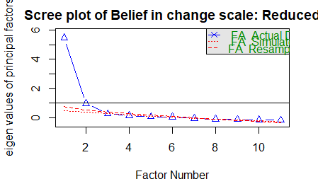

```r
set.seed(123)
parallel = fa.parallel(changefinal,
 fm = 'ml',
 fa = 'fa',
 n.iter = 50,
 main = "Scree plot of Belief in change scale: Reduced",
 SMC = TRUE)
```

#### EFA - items removed - one factor

```r
efa_fi_1 <- fa(changefinal, nfactors = 1, fm = "ml", rotate = "geominQ")
chi_fi_1 <- efa_fi_1$chi # <- Getting Chi square value
dof_fi_1 <- efa_fi_1$dof # <- Getting degrees of freedom
efa_fi_1
```

```
Factor Analysis using method =  ml
Call: fa(r = changefinal, nfactors = 1, rotate = "geominQ", fm = "ml")
Standardized loadings (pattern matrix) based upon correlation matrix
            ML1   h2   u2 com
change1_1  0.72 0.52 0.48   1
change1_4R 0.85 0.73 0.27   1
change1_5  0.72 0.52 0.48   1
change1_6R 0.85 0.72 0.28   1
change1_8  0.72 0.51 0.49   1
change1_9R 0.91 0.82 0.18   1
change2_1  0.48 0.23 0.77   1
change2_2R 0.46 0.22 0.78   1
change2_5R 0.66 0.43 0.57   1
change2_7R 0.64 0.40 0.60   1
change2_10 0.45 0.20 0.80   1

                ML1
SS loadings    5.30
Proportion Var 0.48

Mean item complexity =  1
Test of the hypothesis that 1 factor is sufficient.

The degrees of freedom for the null model are  55  and the objective function was  6.96 with Chi Square of  1165.32
The degrees of freedom for the model are 44  and the objective function was  1.47

The root mean square of the residuals (RMSR) is  0.11
The df corrected root mean square of the residuals is  0.12

The harmonic number of observations is  121 with the empirical chi square  147.36  with prob <  4.5e-13
The total number of observations was  173  with Likelihood Chi Square =  245.54  with prob <  8.4e-30

Tucker Lewis Index of factoring reliability =  0.772
RMSEA index =  0.166  and the 90 % confidence intervals are  0.144 0.183
BIC =  18.8
Fit based upon off diagonal values = 0.96
Measures of factor score adequacy
                                                   ML1
Correlation of (regression) scores with factors   0.97
Multiple R square of scores with factors          0.94
Minimum correlation of possible factor scores     0.88
```

#### EFA - items removed - two factors

```r
efa_fi_2 <- fa(changefinal, nfactors = 2, fm = "ml", rotate = "geominQ")
chi_fi_2 <- efa_fi_2$chi # <- #get Chi square value
dof_fi_2 <- efa_fi_2$dof # <- Getting degressod of freedom
efa_fi_2
```

```
Factor Analysis using method =  ml
Call: fa(r = changefinal, nfactors = 2, rotate = "geominQ", fm = "ml")
Standardized loadings (pattern matrix) based upon correlation matrix
             ML1   ML2   h2   u2 com
change1_1   0.72  0.01 0.53 0.47 1.0
change1_4R  0.80  0.08 0.73 0.27 1.0
change1_5   0.61  0.15 0.50 0.50 1.1
change1_6R  0.92 -0.06 0.78 0.22 1.0
change1_8   0.78 -0.07 0.54 0.46 1.0
change1_9R  0.86  0.08 0.84 0.16 1.0
change2_1   0.04  0.58 0.37 0.63 1.0
change2_2R -0.09  0.74 0.48 0.52 1.0
change2_5R  0.02  0.87 0.78 0.22 1.0
change2_7R  0.14  0.67 0.59 0.41 1.1
change2_10  0.02  0.56 0.33 0.67 1.0

                       ML1  ML2
SS loadings           3.88 2.59
Proportion Var        0.35 0.24
Cumulative Var        0.35 0.59
Proportion Explained  0.60 0.40
Cumulative Proportion 0.60 1.00

 With factor correlations of
     ML1  ML2
ML1 1.00 0.63
ML2 0.63 1.00

Mean item complexity =  1
Test of the hypothesis that 2 factors are sufficient.

The degrees of freedom for the null model are  55  and the objective function was  6.96 with Chi Square of  1165.32
The degrees of freedom for the model are 34  and the objective function was  0.55

The root mean square of the residuals (RMSR) is  0.04
The df corrected root mean square of the residuals is  0.05

The harmonic number of observations is  121 with the empirical chi square  23.29  with prob <  0.92
The total number of observations was  173  with Likelihood Chi Square =  92.01  with prob <  3e-07

Tucker Lewis Index of factoring reliability =  0.915
RMSEA index =  0.102  and the 90 % confidence intervals are  0.075 0.124
BIC =  -83.2
Fit based upon off diagonal values = 0.99
Measures of factor score adequacy
                                                   ML1  ML2
Correlation of (regression) scores with factors   0.97 0.94
Multiple R square of scores with factors          0.94 0.88
Minimum correlation of possible factor scores     0.87 0.76
```

#### EFA - items removed - three factors

```r
efa_fi_3 <- fa(changefinal, nfactors = 3, fm = "ml", rotate = "geominQ")
chi_fi_3 <- efa_fi_3$chi # <- #get Chi square value
dof_fi_3 <- efa_fi_3$dof # <- Getting degrees of freedom
efa_fi_3
```

```
Factor Analysis using method =  ml
Call: fa(r = changefinal, nfactors = 3, rotate = "geominQ", fm = "ml")
Standardized loadings (pattern matrix) based upon correlation matrix
             ML1   ML2   ML3   h2    u2 com
change1_1   0.72  0.00  0.23 0.62 0.380 1.2
change1_4R  0.78  0.09 -0.03 0.70 0.304 1.0
change1_5   0.62  0.14  0.08 0.53 0.473 1.1
change1_6R  0.89 -0.05 -0.03 0.74 0.255 1.0
change1_8   0.79 -0.08  0.08 0.58 0.420 1.0
change1_9R  0.95  0.03 -0.33 0.97 0.028 1.2
change2_1   0.01  0.62  0.42 0.55 0.452 1.8
change2_2R -0.07  0.73 -0.05 0.49 0.514 1.0
change2_5R  0.04  0.86  0.02 0.77 0.225 1.0
change2_7R  0.16  0.66 -0.07 0.60 0.399 1.1
change2_10  0.01  0.57  0.20 0.36 0.636 1.2

                       ML1  ML2  ML3
SS loadings           3.98 2.56 0.37
Proportion Var        0.36 0.23 0.03
Cumulative Var        0.36 0.59 0.63
Proportion Explained  0.58 0.37 0.05
Cumulative Proportion 0.58 0.95 1.00

 With factor correlations of
     ML1   ML2   ML3
ML1 1.00  0.62  0.12
ML2 0.62  1.00 -0.05
ML3 0.12 -0.05  1.00

Mean item complexity =  1.2
Test of the hypothesis that 3 factors are sufficient.

The degrees of freedom for the null model are  55  and the objective function was  6.96 with Chi Square of  1165.32
The degrees of freedom for the model are 25  and the objective function was  0.31

The root mean square of the residuals (RMSR) is  0.03
The df corrected root mean square of the residuals is  0.04

The harmonic number of observations is  121 with the empirical chi square  10.8  with prob <  0.99
The total number of observations was  173  with Likelihood Chi Square =  50.87  with prob <  0.0017

Tucker Lewis Index of factoring reliability =  0.948
RMSEA index =  0.081  and the 90 % confidence intervals are  0.046 0.108
BIC =  -77.96
Fit based upon off diagonal values = 1
Measures of factor score adequacy
                                                   ML1  ML2  ML3
Correlation of (regression) scores with factors   0.98 0.94 0.80
Multiple R square of scores with factors          0.95 0.88 0.63
Minimum correlation of possible factor scores     0.91 0.76 0.27
```

#### 1-factor & 2-factor Model Comparison

```r
chi_diff <- chi_fi_1 - chi_fi_2
dof_diff <- dof_fi_1 - dof_fi_2
pchisq(chi_diff, df=dof_diff, lower.tail=FALSE)
```

```
[1] 7.549636e-22
```

The p-value for a chi-square difference (X^2 = 124.07, df = 10) test of 7.549636e-22 is an indication that the the 2-factor model has a much better fit than the 1-factor model.

#### 2-factor & 3-factor comparison

```r
chi_diff <- chi_fi_2 - chi_fi_3
dof_diff <- dof_fi_2 - dof_fi_3
pchisq(chi_diff, df=dof_diff, lower.tail=FALSE)
```

```
[1] 0.1870661
```

The p-value for a chi-square difference (X^2 = 12.49, df = 9) test of 0.1870661 is an indication that the the 3-factor model does **NOT** have a better fit than the 2 factor model.

# Convergent measures

## Reverse code convergent items

```r
data2 <- data2 %>%
  mutate(pc_comm_1R = 6-pc_comm_1, BF1_22R = 7-BF1_22, BF2_9R = 7-BF2_9, BF2_14R = 7-BF2_14, BF2_19R = 7-BF2_19, BF2_25R = 7-BF2_25, BF2_10R = 7-BF2_10, BF2_15R = 7-BF2_15, BF2_18R = 7-BF2_18, BF2_24R = 7-BF2_24, BF2_11R = 7-BF2_11, BF2_16R = 7-BF2_16, BF2_13R = 7-BF2_13, BF2_1R = 7-BF2_1, BF1_17R = 7-BF1_17, BF1_18R = 7-BF1_18, BF2_5R = 7-BF2_5, BF2_6R = 7-BF2_6, BF2_12R = 7-BF2_12, BF2_21R = 7-BF2_21, BF2_3R = 7-BF2_3, BF2_20R = 7-BF2_20, BF2_23R = 7-BF2_23, BF2_22R = 7-BF2_22, BF2_2R = 7-BF2_2)
```

## CFA - Big Five

```r
modelBF <- 'f1 =~ BF1_2 + BF1_7 + BF1_11 + BF1_12 + BF1_23 + BF1_24 + BF2_10R + BF2_15R + BF2_18R + BF2_24R
f2 =~ BF1_3 + BF1_8 + BF1_13 + BF1_14 + BF1_25 + BF2_1R + BF2_4 + BF2_11R + BF2_13R + BF2_16R
f3 =~ BF1_1 + BF1_6 + BF1_15 + BF1_16 + BF1_21 + BF1_22R + BF2_9R + BF2_14R + BF2_19R + BF2_25R
f4 =~ BF1_5 + BF1_10 + BF1_19 + BF1_20 + BF2_2R + BF2_7 + BF2_8 + BF2_17 + BF2_22R + BF2_23R
f5 =~ BF1_4 + BF1_9 + BF1_17R + BF1_18R + BF2_3R + BF2_5R + BF2_6R + BF2_12R + BF2_20R + BF2_21R'
fit.modelBF <- cfa(modelBF, data2)
summary(fit.modelBF, fit.measures = TRUE, standardized = TRUE)
```

```
lavaan (0.5-23.1097) converged normally after  52 iterations

                                                  Used       Total
  Number of observations                            94         173

  Estimator                                         ML
  Minimum Function Test Statistic             2178.857
  Degrees of freedom                              1165
  P-value (Chi-square)                           0.000

Model test baseline model:

  Minimum Function Test Statistic             3992.886
  Degrees of freedom                              1225
  P-value                                        0.000

User model versus baseline model:

  Comparative Fit Index (CFI)                    0.634
  Tucker-Lewis Index (TLI)                       0.615

Loglikelihood and Information Criteria:

  Loglikelihood user model (H0)              -6534.050
  Loglikelihood unrestricted model (H1)      -5444.621

  Number of free parameters                        110
  Akaike (AIC)                               13288.100
  Bayesian (BIC)                             13567.862
  Sample-size adjusted Bayesian (BIC)        13220.592

Root Mean Square Error of Approximation:

  RMSEA                                          0.096
  90 Percent Confidence Interval          0.090  0.102
  P-value RMSEA <= 0.05                          0.000

Standardized Root Mean Square Residual:

  SRMR                                           0.116
```

[output cut: 123 more lines]

```
   .BF1_4             0.884    0.136    6.505    0.000    0.884    0.612
   .BF1_9             0.745    0.127    5.864    0.000    0.745    0.363
   .BF1_17R           1.132    0.174    6.485    0.000    1.132    0.599
   .BF1_18R           0.929    0.141    6.598    0.000    0.929    0.682
   .BF2_3R            0.832    0.129    6.466    0.000    0.832    0.587
   .BF2_5R            0.704    0.112    6.292    0.000    0.704    0.497
   .BF2_6R            0.903    0.144    6.278    0.000    0.903    0.491
   .BF2_12R           1.131    0.169    6.686    0.000    1.131    0.764
   .BF2_20R           0.335    0.080    4.167    0.000    0.335    0.171
   .BF2_21R           0.985    0.151    6.517    0.000    0.985    0.620
    f1                0.800    0.160    4.997    0.000    1.000    1.000
    f2                0.376    0.133    2.832    0.005    1.000    1.000
    f3                1.140    0.247    4.618    0.000    1.000    1.000
    f4                0.375    0.113    3.319    0.001    1.000    1.000
    f5                0.561    0.172    3.259    0.001    1.000    1.000
```

```r
resid(fit.modelBF, type = "cor")
```

```
$type
[1] "cor.bollen"

$cor
        BF1_2  BF1_7  BF1_11 BF1_12 BF1_23 BF1_24 BF2_10 BF2_15 BF2_18 BF2_24 BF1_3  BF1_8  BF1_13 BF1_14 BF1_25 BF2_1R BF2_4  BF2_11
BF1_2    0.000
BF1_7   -0.054  0.000
BF1_11  -0.108  0.324  0.000
BF1_12  -0.007 -0.188 -0.071  0.000
BF1_23  -0.004  0.461  0.346 -0.122  0.000
BF1_24   0.043 -0.034  0.123 -0.004  0.008  0.000
BF2_10R  0.006 -0.001  0.001  0.023 -0.037 -0.028  0.000
BF2_15R -0.074  0.005  0.127  0.028  0.036  0.069 -0.005  0.000
BF2_18R -0.012  0.129 -0.022 -0.030  0.180 -0.101 -0.004  0.056  0.000
BF2_24R -0.056  0.204  0.095 -0.114  0.174 -0.018 -0.025  0.271  0.245  0.000
BF1_3    0.118  0.059 -0.107  0.068 -0.046  0.050  0.209  0.033  0.065  0.138  0.000
BF1_8    0.271  0.163 -0.063  0.206  0.151  0.253  0.203  0.078  0.131  0.092  0.142  0.000
BF1_13  -0.033 -0.146  0.023  0.108 -0.191 -0.082  0.089  0.095 -0.066 -0.002 -0.006 -0.115  0.000
BF1_14  -0.030  0.141  0.168 -0.149 -0.097 -0.075  0.057 -0.020 -0.039  0.006  0.073  0.007 -0.037  0.000
BF1_25   0.052 -0.051  0.030  0.002 -0.149 -0.024  0.017  0.064 -0.037 -0.037  0.099  0.019  0.036  0.257  0.000
BF2_1R  -0.018 -0.100 -0.099  0.033  0.023  0.079  0.081  0.290  0.030  0.179  0.119  0.025 -0.072 -0.100 -0.041  0.000
BF2_4    0.042 -0.021 -0.054 -0.021 -0.011  0.122  0.097 -0.062  0.000  0.132  0.282  0.321 -0.145 -0.018 -0.114  0.224  0.000
BF2_11R -0.140 -0.101 -0.029 -0.077 -0.215 -0.014 -0.073  0.029 -0.149 -0.036 -0.107 -0.047  0.007  0.027 -0.075 -0.058 -0.065  0.000
BF2_13R -0.045 -0.002  0.048  0.024 -0.132 -0.171  0.012 -0.092 -0.079  0.019 -0.057  0.064  0.042 -0.014 -0.062 -0.053  0.052  0.084
BF2_16R  0.008 -0.232  0.004  0.101 -0.154  0.111  0.063  0.232 -0.102 -0.010  0.073 -0.023 -0.012 -0.061 -0.001  0.185  0.020  0.009
        BF2_13 BF2_16 BF1_1  BF1_6  BF1_15 BF1_16 BF1_21 BF1_22 BF2_9R BF2_14 BF2_19 BF2_25 BF1_5  BF1_10 BF1_19 BF1_20 BF2_2R BF2_7
BF1_2
BF1_7
BF1_11
BF1_12
BF1_23
BF1_24
BF2_10R
BF2_15R
BF2_18R
BF2_24R
BF1_3
BF1_8
BF1_13
BF1_14
```

[output cut: 21 more lines]

```
BF1_25
BF2_1R
BF2_4
BF2_11R
BF2_13R
BF2_16R
 [ reached getOption("max.print") -- omitted 30 rows ]

$mean
  BF1_2   BF1_7  BF1_11  BF1_12  BF1_23  BF1_24 BF2_10R BF2_15R BF2_18R BF2_24R   BF1_3   BF1_8  BF1_13  BF1_14  BF1_25  BF2_1R   BF2_4
      0       0       0       0       0       0       0       0       0       0       0       0       0       0       0       0       0
BF2_11R BF2_13R BF2_16R   BF1_1   BF1_6  BF1_15  BF1_16  BF1_21 BF1_22R  BF2_9R BF2_14R BF2_19R BF2_25R   BF1_5  BF1_10  BF1_19  BF1_20
      0       0       0       0       0       0       0       0       0       0       0       0       0       0       0       0       0
 BF2_2R   BF2_7   BF2_8  BF2_17 BF2_22R BF2_23R   BF1_4   BF1_9 BF1_17R BF1_18R  BF2_3R  BF2_5R  BF2_6R BF2_12R BF2_20R BF2_21R
      0       0       0       0       0       0       0       0       0       0       0       0       0       0       0       0
```

```r
reliability(fit.modelBF)
```

```
              f1        f2        f3        f4        f5     total
alpha  0.8329378 0.8375420 0.9248551 0.8130443 0.8956293 0.9096722
omega  0.8175350 0.8518079 0.9278460 0.8064115 0.8969527 0.9397623
omega2 0.8175350 0.8518079 0.9278460 0.8064115 0.8969527 0.9397623
omega3 0.7377652 0.8355100 0.9293333 0.7734384 0.8803482 0.9478351
avevar 0.3422902 0.4096281 0.5688755 0.3078599 0.4784831 0.4401534
```

## CFA - perceived control at community level

```r
model.PC <- 'f1 =~ pc_comm_1 + pc_comm_2 + pc_comm_3 + pc_comm_4 + pc_comm_5'
fit.model.PC <- cfa(model.PC, data2)
summary(fit.model.PC, fit.measures = TRUE, standardized = TRUE)
```

```
lavaan (0.5-23.1097) converged normally after  49 iterations

                                                  Used       Total
  Number of observations                           118         173

  Estimator                                         ML
  Minimum Function Test Statistic               15.074
  Degrees of freedom                                 5
  P-value (Chi-square)                           0.010

Model test baseline model:

  Minimum Function Test Statistic               85.079
  Degrees of freedom                                10
  P-value                                        0.000

User model versus baseline model:

  Comparative Fit Index (CFI)                    0.866
  Tucker-Lewis Index (TLI)                       0.732

Loglikelihood and Information Criteria:

  Loglikelihood user model (H0)               -670.690
  Loglikelihood unrestricted model (H1)       -663.153

  Number of free parameters                         10
  Akaike (AIC)                                1361.379
  Bayesian (BIC)                              1389.086
  Sample-size adjusted Bayesian (BIC)         1357.474

Root Mean Square Error of Approximation:

  RMSEA                                          0.131
  90 Percent Confidence Interval          0.058  0.209
  P-value RMSEA <= 0.05                          0.037

Standardized Root Mean Square Residual:

  SRMR                                           0.076
```

[output cut: 8 more lines]

```
  f1 =~
    pc_comm_1         1.000                               0.201    0.201
    pc_comm_2         3.313    1.797    1.843    0.065    0.664    0.816
    pc_comm_3         1.251    0.681    1.838    0.066    0.251    0.564
    pc_comm_4         2.463    1.347    1.828    0.068    0.494    0.539
    pc_comm_5         1.711    1.018    1.681    0.093    0.343    0.346

Variances:
                   Estimate  Std.Err  z-value  P(>|z|)   Std.lv  Std.all
   .pc_comm_1         0.955    0.126    7.572    0.000    0.955    0.960
   .pc_comm_2         0.221    0.093    2.362    0.018    0.221    0.333
   .pc_comm_3         0.135    0.022    6.092    0.000    0.135    0.682
   .pc_comm_4         0.597    0.094    6.338    0.000    0.597    0.710
   .pc_comm_5         0.865    0.118    7.306    0.000    0.865    0.880
    f1                0.040    0.042    0.954    0.340    1.000    1.000
```

```r
resid(fit.model.PC, type = "cor")
```

```
$type
[1] "cor.bollen"

$cor
          pc_c_1 pc_c_2 pc_c_3 pc_c_4 pc_c_5
pc_comm_1  0.000
pc_comm_2  0.092  0.000
pc_comm_3 -0.119 -0.010  0.000
pc_comm_4 -0.042 -0.014  0.041  0.000
pc_comm_5 -0.241 -0.002  0.045  0.023  0.000

$mean
pc_comm_1 pc_comm_2 pc_comm_3 pc_comm_4 pc_comm_5
        0         0         0         0         0
```

```r
reliability(fit.model.PC)
```

```
              f1     total
alpha  0.5035562 0.5035562
omega  0.5789800 0.5789800
omega2 0.5789800 0.5789800
omega3 0.6189400 0.6189400
avevar 0.2462962 0.2462962
```

## CFA - optimism

```r
model.LO <- 'f1 =~ lo_1 + lo_2R + lo_3 + lo_4R + lo_5R + lo_6'
fit.model.LO <- cfa(model.LO, data2)
summary(fit.model.LO, fit.measures = TRUE, standardized = TRUE)
```

```
lavaan (0.5-23.1097) converged normally after  26 iterations

                                                  Used       Total
  Number of observations                           118         173

  Estimator                                         ML
  Minimum Function Test Statistic               50.095
  Degrees of freedom                                 9
  P-value (Chi-square)                           0.000

Model test baseline model:

  Minimum Function Test Statistic              329.814
  Degrees of freedom                                15
  P-value                                        0.000

User model versus baseline model:

  Comparative Fit Index (CFI)                    0.869
  Tucker-Lewis Index (TLI)                       0.782

Loglikelihood and Information Criteria:

  Loglikelihood user model (H0)               -852.568
  Loglikelihood unrestricted model (H1)       -827.520

  Number of free parameters                         12
  Akaike (AIC)                                1729.135
  Bayesian (BIC)                              1762.384
  Sample-size adjusted Bayesian (BIC)         1724.449

Root Mean Square Error of Approximation:

  RMSEA                                          0.197
  90 Percent Confidence Interval          0.146  0.252
  P-value RMSEA <= 0.05                          0.000

Standardized Root Mean Square Residual:

  SRMR                                           0.080
```

[output cut: 10 more lines]

```
    lo_2R             0.978    0.198    4.942    0.000    0.528    0.605
    lo_3              1.108    0.227    4.890    0.000    0.599    0.595
    lo_4R             1.682    0.280    6.013    0.000    0.909    0.893
    lo_5R             1.632    0.282    5.791    0.000    0.882    0.806
    lo_6              1.216    0.222    5.487    0.000    0.657    0.724

Variances:
                   Estimate  Std.Err  z-value  P(>|z|)   Std.lv  Std.all
   .lo_1              0.739    0.101    7.313    0.000    0.739    0.717
   .lo_2R             0.483    0.068    7.137    0.000    0.483    0.634
   .lo_3              0.653    0.091    7.166    0.000    0.653    0.646
   .lo_4R             0.210    0.054    3.915    0.000    0.210    0.203
   .lo_5R             0.420    0.072    5.801    0.000    0.420    0.351
   .lo_6              0.392    0.059    6.616    0.000    0.392    0.476
    f1                0.292    0.099    2.962    0.003    1.000    1.000
```

```r
resid(fit.model.LO, type = "cor")
```

```
$type
[1] "cor.bollen"

$cor
      lo_1   lo_2R  lo_3   lo_4R  lo_5R  lo_6
lo_1   0.000
lo_2R  0.033  0.000
lo_3   0.228  0.088  0.000
lo_4R -0.008 -0.021 -0.067  0.000
lo_5R -0.117 -0.033 -0.103  0.062  0.000
lo_6   0.042  0.041  0.184 -0.035 -0.037  0.000

$mean
 lo_1 lo_2R  lo_3 lo_4R lo_5R  lo_6
    0     0     0     0     0     0
```

```r
reliability(fit.model.LO)
```

```
              f1     total
alpha  0.8524820 0.8524820
omega  0.8538909 0.8538909
omega2 0.8538909 0.8538909
omega3 0.8365133 0.8365133
avevar 0.5057444 0.5057444
```

## CFA - locus of control

```r
model.LC <- 'f1 =~ lc_1 + lc_2R + lc_3 + lc_4R + lc_5 + lc_6R'
fit.model.LC <- cfa(model.LC, data2)
summary(fit.model.LC, fit.measures = TRUE, standardized = TRUE)
```

```
lavaan (0.5-23.1097) converged normally after  31 iterations

                                                  Used       Total
  Number of observations                           117         173

  Estimator                                         ML
  Minimum Function Test Statistic               19.563
  Degrees of freedom                                 9
  P-value (Chi-square)                           0.021

Model test baseline model:

  Minimum Function Test Statistic               98.011
  Degrees of freedom                                15
  P-value                                        0.000

User model versus baseline model:

  Comparative Fit Index (CFI)                    0.873
  Tucker-Lewis Index (TLI)                       0.788

Loglikelihood and Information Criteria:

  Loglikelihood user model (H0)               -899.881
  Loglikelihood unrestricted model (H1)       -890.100

  Number of free parameters                         12
  Akaike (AIC)                                1823.762
  Bayesian (BIC)                              1856.908
  Sample-size adjusted Bayesian (BIC)         1818.975

Root Mean Square Error of Approximation:

  RMSEA                                          0.100
  90 Percent Confidence Interval          0.037  0.161
  P-value RMSEA <= 0.05                          0.083

Standardized Root Mean Square Residual:

  SRMR                                           0.068
```

[output cut: 10 more lines]

```
    lc_2R             1.741    0.514    3.390    0.001    0.580    0.560
    lc_3              1.489    0.474    3.142    0.002    0.496    0.475
    lc_4R             1.059    0.396    2.675    0.007    0.353    0.362
    lc_5              1.102    0.356    3.099    0.002    0.367    0.463
    lc_6R             1.997    0.559    3.570    0.000    0.666    0.685

Variances:
                   Estimate  Std.Err  z-value  P(>|z|)   Std.lv  Std.all
   .lc_1              0.460    0.067    6.824    0.000    0.460    0.805
   .lc_2R             0.737    0.122    6.050    0.000    0.737    0.686
   .lc_3              0.845    0.127    6.648    0.000    0.845    0.774
   .lc_4R             0.824    0.115    7.138    0.000    0.824    0.869
   .lc_5              0.495    0.074    6.715    0.000    0.495    0.786
   .lc_6R             0.501    0.109    4.601    0.000    0.501    0.531
    f1                0.111    0.054    2.069    0.039    1.000    1.000
```

```r
resid(fit.model.LC, type = "cor")
```

```
$type
[1] "cor.bollen"

$cor
      lc_1   lc_2R  lc_3   lc_4R  lc_5   lc_6R
lc_1   0.000
lc_2R  0.000  0.000
lc_3  -0.048  0.113  0.000
lc_4R  0.037 -0.061 -0.056  0.000
lc_5  -0.056  0.045  0.080 -0.187  0.000
lc_6R  0.036 -0.054 -0.069  0.135  0.017  0.000

$mean
 lc_1 lc_2R  lc_3 lc_4R  lc_5 lc_6R
    0     0     0     0     0     0
```

```r
reliability(fit.model.LC)
```

```
              f1     total
alpha  0.6559813 0.6559813
omega  0.6692946 0.6692946
omega2 0.6692946 0.6692946
omega3 0.6738153 0.6738153
avevar 0.2656008 0.2656008
```

## Calculate convergent scale scores

```r
# perceived control at comm level
data2$scalePC <- rowMeans(data2[ , c("pc_comm_1", "pc_comm_2", "pc_comm_3", "pc_comm_4","pc_comm_5")])
# life orientation (optimism)
data2$scaleLO <- rowMeans(data2[ , c("lo_1", "lo_2R", "lo_3", "lo_4R", "lo_5R", "lo_6")])
# locus of control
data2$scaleLC <- rowMeans(data2[ , c("lc_1", "lc_2R", "lc_3", "lc_4R", "lc_5", "lc_6R")])
# agreeableness
data2$scaleagree <- rowMeans(data2[ , c("BF1_2", "BF1_7", "BF1_11", "BF1_12", "BF1_23", "BF1_24", "BF2_10R", "BF2_15R", "BF2_18R", "BF2_24R")])

# conscientiousness
data2$scalecons <- rowMeans(data2[ , c("BF1_3", "BF1_8", "BF1_13", "BF1_14", "BF1_25", "BF2_1R", "BF2_4", "BF2_11R", "BF2_13R", "BF2_16R")])

# extraversion
data2$scaleextra <- rowMeans(data2[ , c("BF1_1", "BF1_6", "BF1_15", "BF1_16", "BF1_21", "BF1_22R", "BF2_9R", "BF2_14R", "BF2_19R", "BF2_25R")])

# openness/intellect
data2$scaleopen <- rowMeans(data2[ , c("BF1_5", "BF1_10", "BF1_19", "BF1_20", "BF2_2R", "BF2_7", "BF2_8", "BF2_17", "BF2_22R", "BF2_23R")])

# emotional stability
data2$scaleemot <- rowMeans(data2[ , c("BF1_4", "BF1_9", "BF1_17R", "BF1_18R", "BF2_3R", "BF2_5R", "BF2_6R", "BF2_12R", "BF2_20R", "BF2_21R")])
# scale scores for full scale and subscales in full dataset
## previously they were calculated in the dataset with only our scale
data2$scalefull <- rowMeans(data2[ , c("change1_1", "change1_2R", "change1_3", "change1_4R", "change1_5", "change1_6R", "change1_7", "change1_8", "change1_9R", "change2_1", "change2_2R", "change2_3", "change2_4", "change2_5R", "change2_6", "change2_7R", "change2_8", "change2_9R", "change2_10")])
data2$scalegeneral <- rowMeans(data2[ , c("change1_1", "change1_2R", "change1_3", "change1_4R", "change1_5", "change1_6R", "change1_7", "change1_8", "change1_9R")])
data2$scalepersonal <- rowMeans(data2[ , c("change2_1", "change2_2R", "change2_3", "change2_4", "change2_5R", "change2_6", "change2_7R", "change2_8", "change2_9R", "change2_10")])
```

(to easily correlate all scales)

```r
dataSS <- data2 %>%
  select(scalefull, scalegeneral, scalepersonal, scalePC, scaleLC)
```

## Correlation table for all variables

```r
conv <- cor(dataSS, use = "pairwise.complete.obs")
conv
```

```
              scalefull scalegeneral scalepersonal   scalePC   scaleLC
scalefull     1.0000000    0.8959693     0.9330257 0.6884443 0.2878901
scalegeneral  0.8959693    1.0000000     0.6761651 0.6097251 0.1338245
scalepersonal 0.9330257    0.6761651     1.0000000 0.6463894 0.3677403
scalePC       0.6884443    0.6097251     0.6463894 1.0000000 0.1444473
scaleLC       0.2878901    0.1338245     0.3677403 0.1444473 1.0000000
```

```r
apa.cor.table(conv, show.conf.interval = FALSE, filename = "convergent.doc")
```

```
The ability to suppress reporting of reporting confidence intervals has been deprecated in this version.
The function argument show.conf.interval will be removed in a later version.


Means, standard deviations, and correlations with confidence intervals


  Variable         M    SD   1           2           3           4
  1. scalefull     0.76 0.29

  2. scalegeneral  0.66 0.34 .92*
                             [.21, .99]

  3. scalepersonal 0.72 0.25 .91*        .67
                             [.13, .99]  [-.51, .98]

  4. scalePC       0.62 0.31 .61         .59         .52
                             [-.59, .97] [-.61, .97] [-.67, .96]

  5. scaleLC       0.39 0.36 -.81        -.88        -.59        -.89*
                             [-.99, .26] [-.99, .02] [-.97, .61] [-.99, -.03]


Note. M and SD are used to represent mean and standard deviation, respectively.
Values in square brackets indicate the 95% confidence interval.
The confidence interval is a plausible range of population correlations
that could have caused the sample correlation (Cumming, 2014).
* indicates p < .05. ** indicates p < .01.
```

```r
psych::alpha(change)
```

```
Reliability analysis
Call: psych::alpha(x = change)

  raw_alpha std.alpha G6(smc) average_r S/N    ase mean  sd
      0.94      0.94    0.96      0.47  17 0.0068    4 0.5

 lower alpha upper     95% confidence boundaries
0.92 0.94 0.95

 Reliability if an item is dropped:
           raw_alpha std.alpha G6(smc) average_r S/N alpha se    NA
change1_1       0.93      0.94    0.96      0.47  16   0.0072 0.013
change1_2R      0.94      0.94    0.96      0.48  16   0.0070 0.014
change1_3       0.94      0.94    0.96      0.47  16   0.0071 0.014
change1_4R      0.93      0.94    0.96      0.46  16   0.0073 0.014
change1_5       0.93      0.94    0.96      0.47  16   0.0072 0.014
change1_6R      0.93      0.94    0.96      0.46  16   0.0072 0.013
change1_7       0.94      0.94    0.96      0.47  16   0.0072 0.014
change1_8       0.94      0.94    0.96      0.47  16   0.0071 0.013
change1_9R      0.93      0.94    0.96      0.46  15   0.0073 0.013
change2_1       0.94      0.94    0.96      0.47  16   0.0071 0.014
change2_2R      0.94      0.94    0.96      0.48  17   0.0067 0.013
change2_3       0.93      0.94    0.96      0.46  16   0.0072 0.014
change2_4       0.93      0.94    0.96      0.47  16   0.0072 0.013
change2_5R      0.93      0.94    0.96      0.46  16   0.0074 0.014
change2_6       0.94      0.94    0.96      0.47  16   0.0071 0.015
change2_7R      0.93      0.94    0.96      0.47  16   0.0073 0.015
change2_8       0.93      0.94    0.96      0.47  16   0.0073 0.015
change2_9R      0.94      0.94    0.96      0.47  16   0.0072 0.015
change2_10      0.94      0.94    0.96      0.48  16   0.0069 0.014

 Item statistics
             n raw.r std.r r.cor r.drop mean   sd
change1_1  122  0.72  0.74  0.73   0.69  4.2 0.56
change1_2R 122  0.62  0.62  0.60   0.57  4.3 0.77
change1_3  122  0.66  0.68  0.67   0.62  4.2 0.62
change1_4R 122  0.76  0.76  0.76   0.72  3.9 0.74
change1_5  122  0.70  0.72  0.71   0.67  4.3 0.58
change1_6R 122  0.74  0.76  0.76   0.71  4.2 0.68
change1_7  122  0.72  0.75  0.74   0.69  4.2 0.49
```

[output cut: 19 more lines]

```
change1_5  0.00 0.02 0.02 0.65 0.32 0.29
change1_6R 0.00 0.03 0.07 0.61 0.30 0.29
change1_7  0.00 0.01 0.01 0.74 0.25 0.29
change1_8  0.01 0.04 0.07 0.67 0.21 0.29
change1_9R 0.00 0.03 0.07 0.61 0.29 0.29
change2_1  0.00 0.03 0.12 0.53 0.32 0.30
change2_2R 0.01 0.17 0.17 0.51 0.13 0.30
change2_3  0.00 0.01 0.07 0.65 0.27 0.30
change2_4  0.00 0.02 0.09 0.62 0.26 0.30
change2_5R 0.00 0.04 0.19 0.60 0.17 0.31
change2_6  0.00 0.02 0.07 0.65 0.25 0.30
change2_7R 0.00 0.02 0.11 0.64 0.22 0.30
change2_8  0.00 0.07 0.27 0.51 0.14 0.30
change2_9R 0.01 0.21 0.18 0.45 0.16 0.30
change2_10 0.01 0.17 0.25 0.47 0.11 0.30
```